# Getting Started with rmet

Brazil’s National Institute of Meteorology (INMET) maintains a network of automatic weather stations that record hourly observations across the country. The raw data are distributed as annual ZIP archives containing CSV files, one per station, with formatting inconsistencies that vary across years (e.g., different date formats, trailing semicolons, phantom columns, and mixed encodings). `rmet` automates the full pipeline: downloading those archives, resolving their structural quirks, and returning a clean, analysis-ready `data.frame`.

## Installation

```r
# install.packages("devtools")
devtools::install_github("rodrigosqrt3/rmet")
```

```r
library(rmet)
```

## Step 1 — Browse the station catalogue

The package ships with a bundled catalogue of all automatic INMET stations. `inmet_stations()` lets you filter by state, so you can confirm station codes before downloading anything.

```r
stations <- inmet_stations(state = "RS")
head(stations[, c("code", "name", "latitude", "longitude", "elevation")])
```

Station **A801** is the Porto Alegre automatic station, located at roughly −30.05 °S, −51.17 °W, 46.97 m above sea level.

## Step 2 — Download annual archives

`inmet_download()` fetches the annual ZIP files from INMET’s servers and saves them to a persistent local cache. Downloads are resumable: if a connection drops, re-running the same call picks up where it left off.

```r
# Downloads the 2023 archive (~70 MB) to the default cache directory.
# Safe to re-run — skips files that are already complete.
inmet_download(2023)
```

You can inspect what is already cached at any time:

```r
inmet_cache_status()
```

## Step 3 — Read data into R

`inmet_read()` parses the ZIP archives directly — no manual extraction needed. It normalises column names, converts all measurement columns to `numeric`, parses timestamps, and shifts UTC to local Brazilian time.

```r
df <- inmet_read(
  years      = 2023,
  stations   = "A801",
  start_date = "2023-01-01",
  end_date   = "2023-12-31"
)
```

The examples below use the package’s built-in sample dataset, which contains one year of hourly observations from station A801 (Porto Alegre, 2023).

```r
df <- rmet_example
str(df[, c("datetime", "station_code", "state",
           "temp_dry_c", "precip_mm", "humid_rel_pct",
           "wind_speed_ms", "pressure_station_hpa")])
```

```
#> 'data.frame':    8663 obs. of  8 variables:
#>  $ datetime            : POSIXct, format: "2022-12-31 21:00:00" "2022-12-31 22:00:00" ...
#>  $ station_code        : chr  "A801" "A801" "A801" "A801" ...
#>  $ state               : chr  "RS" "RS" "RS" "RS" ...
#>  $ temp_dry_c          : num  26.5 26.8 26.3 25.2 24.1 23.1 22 21.5 21 21.1 ...
#>  $ precip_mm           : num  0 0 0 0 0 0 0 0 0 0 ...
#>  $ humid_rel_pct       : int  55 49 50 59 65 73 81 89 91 91 ...
#>  $ wind_speed_ms       : num  2 1.9 1.5 1.4 1.1 1.1 1.1 1.2 0.9 1.2 ...
#>  $ pressure_station_hpa: num  1006 1007 1007 1006 1006 ...
```

## Exploring the data

### Daily aggregation

Hourly data are often most useful after aggregating to daily summaries.

```r
df$date <- as.Date(df$datetime)

daily <- aggregate(
  cbind(temp_dry_c, precip_mm, humid_rel_pct, wind_speed_ms) ~ date,
  data = df,
  FUN  = function(x) mean(x, na.rm = TRUE)
)

daily$temp_max <- aggregate(temp_dry_c ~ date, df, max, na.rm = TRUE)$temp_dry_c
daily$temp_min <- aggregate(temp_dry_c ~ date, df, min, na.rm = TRUE)$temp_dry_c
daily$precip   <- aggregate(precip_mm  ~ date, df, sum, na.rm = TRUE)$precip_mm
daily$month    <- as.integer(format(daily$date, "%m"))
```

### Temperature series

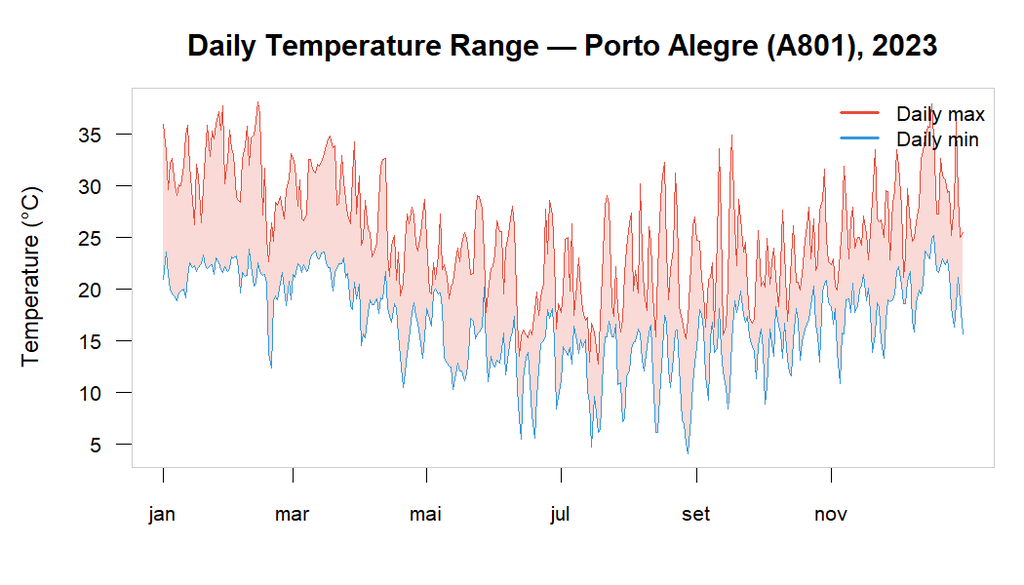

Daily temperature range at Porto Alegre (A801) — 2023.

```r
col_max  <- "#E74C3C"
col_min  <- "#3498DB"
col_band <- "#F1948A"

par(
  mar     = c(4, 4.5, 3, 1),
  family  = "sans",
  cex.lab = 0.95,
  cex.axis = 0.85
)

plot(
  daily$date, daily$temp_max,
  type = "n",
  ylim = range(c(daily$temp_min, daily$temp_max), na.rm = TRUE),
  xlab = "",
  ylab = "Temperature (\u00b0C)",
  main = "Daily Temperature Range \u2014 Porto Alegre (A801), 2023",
  axes = FALSE
)

# shaded band between min and max
polygon(
  c(daily$date, rev(daily$date)),
  c(daily$temp_max, rev(daily$temp_min)),
  col    = adjustcolor(col_band, alpha.f = 0.35),
  border = NA
)

lines(daily$date, daily$temp_max, col = col_max, lwd = 1.2)
lines(daily$date, daily$temp_min, col = col_min, lwd = 1.2)

axis(1,
     at     = seq(min(daily$date), max(daily$date), by = "2 months"),
     labels = format(seq(min(daily$date), max(daily$date), by = "2 months"), "%b"),
     las    = 1)
axis(2, las = 1)
box(col = "grey80")

legend(
  "topright",
  legend = c("Daily max", "Daily min"),
  col    = c(col_max, col_min),
  lwd    = 2,
  bty    = "n",
  cex    = 0.85
)
```

### Precipitation

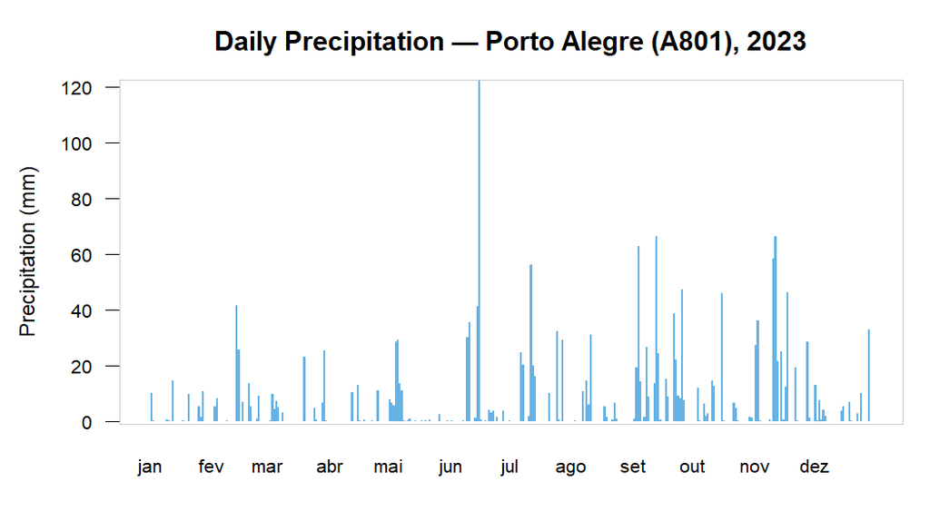

Daily accumulated precipitation at Porto Alegre (A801) — 2023.

```r
col_prec <- "#3498DB"

par(mar = c(4, 4.5, 3, 1), family = "sans", cex.lab = 0.95, cex.axis = 0.85)

barplot(
  daily$precip,
  col    = adjustcolor(col_prec, alpha.f = 0.75),
  border = NA,
  space  = 0,
  xlab   = "",
  ylab   = "Precipitation (mm)",
  main   = "Daily Precipitation \u2014 Porto Alegre (A801), 2023",
  axes   = FALSE
)

axis(2, las = 1)

# Month labels on x axis
month_starts <- which(!duplicated(format(daily$date, "%m")))
axis(1,
     at     = month_starts,
     labels = format(daily$date[month_starts], "%b"),
     tick   = FALSE)

box(col = "grey80")
```

### Monthly temperature boxplots

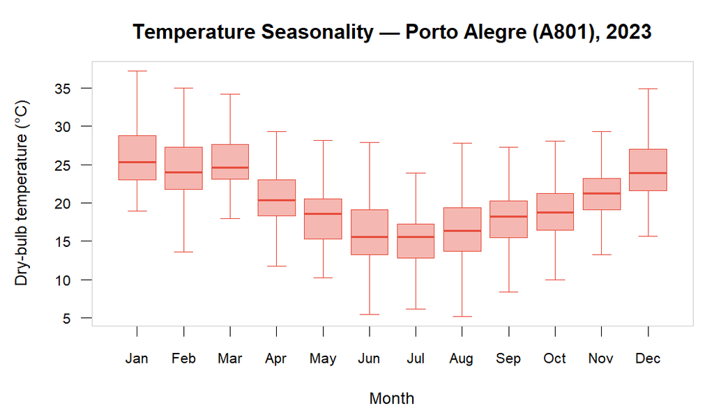

Seasonal cycle of hourly dry-bulb temperature at Porto Alegre (A801) — 2023.

```r
col_box <- "#E74C3C"

df$month <- as.integer(format(df$datetime, "%m"))
month_labels <- c("Jan","Feb","Mar","Apr","May","Jun",
                  "Jul","Aug","Sep","Oct","Nov","Dec")

par(mar = c(4, 4.5, 3, 1), family = "sans", cex.lab = 0.95, cex.axis = 0.85)

boxplot(
  temp_dry_c ~ month,
  data     = df,
  col      = adjustcolor(col_box, alpha.f = 0.40),
  border   = col_box,
  names    = month_labels,
  xlab     = "Month",
  ylab     = "Dry-bulb temperature (\u00b0C)",
  main     = "Temperature Seasonality \u2014 Porto Alegre (A801), 2023",
  outline  = FALSE,
  whisklty = 1,
  medlwd   = 2,
  axes     = FALSE
)

axis(1, at = 1:12, labels = month_labels, las = 1)
axis(2, las = 1)
box(col = "grey80")
```